# Demo: Multiple Regression

CRISP-DM Phase 4 — Modeling

Autor:in

Prof. Dr. Jörg Schoder

Veröffentlichungsdatum

18. März 2026

**HinweisPurpose of this Document**

This document serves **two purposes:**

1. **For the instructor:** A fully annotated step-by-step guide for the live demo in RStudio. Step by step—with explanations of what is being demonstrated and why.
2. **For students:** Available as a reference document after the session. All steps are reproducible and can be followed independently.

## Starting Point: What Do We Have So Far?

In Lab 2, we estimated the **baseline model** `Sales ~ Price`:

```r
mod_baseline <- tbl_carseats %>%
  lm(Sales ~ Price, data = .)

mod_baseline %>%
  get_regression_summaries() %>%
  select(r_squared, rmse) %>%
  mutate(modell = "Baseline: Sales ~ Price") %>%
  relocate(modell) %>%
  gt() %>%
  fmt_number(columns = c(r_squared, rmse), decimals = 4) %>%
  tab_options(table.font.size = "13px")
```

| modell | r_squared | rmse |
| --- | --- | --- |
| Baseline: Sales ~ Price | 0.1980 | 2.5260 |

**WichtigThe Problem: Omitted Variable Bias**

$R^2 \approx$ 0.2 — price alone explains very little. And the residual plot showed a systematic pattern based on `ShelveLoc`.

**Diagnosis:** `ShelveLoc` is a **confounder** — it correlates with both `Price` (stores with good shelf space can charge higher prices) and with `Sales` (good shelf space directly increases sales).

**Solution:** Include `ShelveLoc` and `Advertising` in the model.

## Step 1: Understanding Dummy Encoding

### How R Handles Categorical Variables

```r
# ShelveLoc is in class character — R converts automatically
class(tbl_carseats$ShelveLoc)
```

```
[1] "factor"
```

```r
levels(factor(tbl_carseats$ShelveLoc))
```

```
[1] "Bad"    "Good"   "Medium"
```

R automatically encodes `ShelveLoc` into **dummy variables** (one-hot encoding with a reference category):

| ShelveLoc | (Intercept) | ShelveLocGood | ShelveLocMedium |
| --- | --- | --- | --- |
| Bad | ✅ Referenz | 0 | 0 |
| Medium | — | 0 | 1 |
| Good | — | 1 | 0 |

Bad = Referenzkategorie (alphabetisch erste Kategorie)

**HinweisWhy a reference category?**

With $k$ categories, we only need $k-1$ dummy variables—otherwise, **perfect multicollinearity** occurs (the dummy variables always sum to 1).

The reference category (**Bad**) is included in the **intercept**. All other coefficients measure the **difference** from the reference.

### Visualization: Sales by ShelveLoc

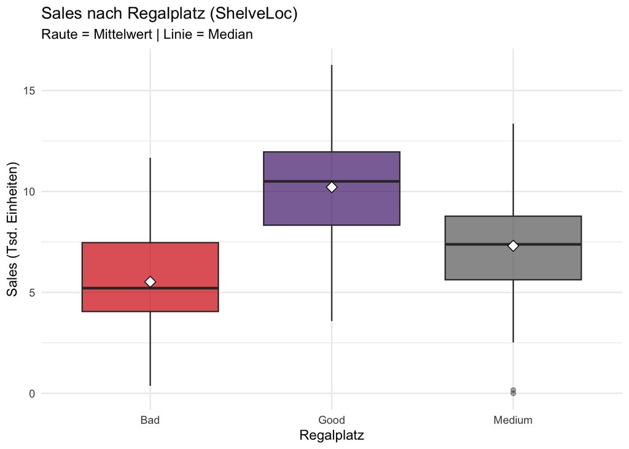

```r
tbl_carseats %>%
  ggplot(aes(x = ShelveLoc, y = Sales, fill = ShelveLoc)) +
  geom_boxplot(alpha = 0.7, outlier.alpha = 0.4) +
  stat_summary(fun = mean, geom = "point",
               shape = 23, size = 3, fill = "white") +
  scale_fill_manual(values = c("Bad"    = "#D50006",
                               "Medium" = "#686868",
                               "Good"   = "#502479")) +
  labs(
    title    = "Sales nach Regalplatz (ShelveLoc)",
    subtitle = "Raute = Mittelwert | Linie = Median",
    x = "Regalplatz", y = "Sales (Tsd. Einheiten)"
  ) +
  theme_minimal(base_size = 11) +
  theme(legend.position = "none")
```

## Step 2: Estimate multiple regression model

### The model

$$\widehat{\text{Sales}} = \hat\beta_0 + \hat\beta_1 \cdot \text{Price} + \hat\beta_2 \cdot \text{Advertising} + \hat\beta_3 \cdot \mathbf{1}_{\text{Good}} + \hat\beta_4 \cdot \mathbf{1}_{\text{Medium}}$$

```r
mod_multipel <- tbl_carseats %>%
  lm(Sales ~ Price + Advertising + ShelveLoc, data = .)

mod_multipel %>%
  get_regression_table() %>%
  gt() %>%
  fmt_number(columns = c(estimate, std_error, statistic,
                         p_value, lower_ci, upper_ci),
             decimals = 4) %>%
  tab_style(
    style     = cell_fill(color = "#f5f0fa"),
    locations = cells_body(rows = str_detect(term, "ShelveLoc"))
  ) %>%
  tab_style(
    style     = cell_fill(color = "#fff0f0"),
    locations = cells_body(rows = term == "Price")
  ) %>%
  tab_style(
    style     = cell_fill(color = "#f0fff8"),
    locations = cells_body(rows = term == "Advertising")
  ) %>%
  tab_options(table.font.size = "14px") %>%
  tab_footnote("Lila = ShelveLoc-Dummies | Rot = Price | Grün = Advertising")
```

| term | estimate | std_error | statistic | p_value | lower_ci | upper_ci |
| --- | --- | --- | --- | --- | --- | --- |
| intercept | 11.4680 | 0.4710 | 24.3520 | 0.0000 | 10.5420 | 12.3940 |
| Price | −0.0580 | 0.0040 | −15.4040 | 0.0000 | −0.0650 | −0.0510 |
| Advertising | 0.1090 | 0.0130 | 8.1540 | 0.0000 | 0.0830 | 0.1360 |
| ShelveLoc: Good | 4.7760 | 0.2650 | 18.0070 | 0.0000 | 4.2550 | 5.2980 |
| ShelveLoc: Medium | 1.8290 | 0.2170 | 8.4090 | 0.0000 | 1.4010 | 2.2560 |

Lila = ShelveLoc-Dummies | Rot = Price | Grün = Advertising

## Step 3: Interpret coefficients

### Ceteris-Paribus-Logic

**WichtigWhat does *ceteris paribus* mean?**

Each coefficient in the multiple model measures the effect of **one** variable while **holding all others constant** (“all else being equal”).

| Koeffizient | Schätzwert | Interpretation |
| --- | --- | --- |
| (Intercept) | 11.4680 | Ø Sales = 11.47 Tsd. bei Price=0, Adv=0, ShelveLoc=Bad |
| Price | -0.0580 | Pro +1 USD Preis → -0.058 Tsd. weniger Sales (c.p.) |
| Advertising | 0.1093 | Pro +1 Tsd. USD Werbung → +0.1093 Tsd. Sales (c.p.) |
| ShelveLocGood | 4.7765 | Good vs. Bad Regalplatz: +4.776 Tsd. Sales (c.p.) |
| ShelveLocMedium | 1.8288 | Medium vs. Bad Regalplatz: +1.829 Tsd. Sales (c.p.) |

### Live Computation: What is the typical branch selling?

```r
# Beispiel: Filiale mit Price=120, Advertising=10, ShelveLoc="Good"
predict(mod_multipel,
        newdata = data.frame(
          Price       = 120,
          Advertising = 10,
          ShelveLoc   = "Good"
        ))
```

```
       1
10.38057
```

```r
# Manuell nachrechnen (zeigt ceteris paribus live)
beta <- coef(mod_multipel)
beta["(Intercept)"] +
  beta["Price"] * 120 +
  beta["Advertising"] * 10 +
  beta["ShelveLocGood"] * 1   # Good = 1
```

```
(Intercept)
   10.38057
```

## Step 4: Compare model quality (fit)

### Baseline vs. Multiple Model

```r
bind_rows(
  mod_baseline %>%
    get_regression_summaries() %>%
    mutate(modell = "Baseline: Sales ~ Price"),
  mod_multipel %>%
    get_regression_summaries() %>%
    mutate(modell = "Multipel: Sales ~ Price + Advertising + ShelveLoc")
) %>%
  select(modell, r_squared, adj_r_squared, rmse, sigma) %>%
  gt() %>%
  fmt_number(columns = c(r_squared, adj_r_squared, rmse, sigma),
             decimals = 4) %>%
  tab_style(
    style     = cell_fill(color = "#f0fff0"),
    locations = cells_body(rows = str_detect(modell, "Multipel"))
  ) %>%
  tab_options(table.font.size = "13px") %>%
  tab_footnote("Grün = deutliche Verbesserung durch zusätzliche Variablen")
```

| modell | r_squared | adj_r_squared | rmse | sigma |
| --- | --- | --- | --- | --- |
| Baseline: Sales ~ Price | 0.1980 | 0.1960 | 2.5260 | 2.5320 |
| Multipel: Sales ~ Price + Advertising + ShelveLoc | 0.6080 | 0.6050 | 1.7649 | 1.7760 |

Grün = deutliche Verbesserung durch zusätzliche Variablen

### Change in the price coefficient (OVB adjustment)

```r
cat("β_Price ohne ShelveLoc:", round(coef(mod_baseline)["Price"], 4), "\n")
```

```
β_Price ohne ShelveLoc: -0.0531
```

```r
cat("β_Price mit ShelveLoc: ", round(coef(mod_multipel)["Price"], 4), "\n")
```

```
β_Price mit ShelveLoc:  -0.058
```

```r
cat("Veränderung:           ",
    round(coef(mod_multipel)["Price"] - coef(mod_baseline)["Price"], 4), "\n")
```

```
Veränderung:            -0.0049
```

**HinweisWhy does the price coefficient change?**

In the baseline model, $\hat\beta_{\text{Price}}$ was **biased** by the confounder `ShelveLoc`:

Stores with good shelf space can charge higher prices AND have higher sales. This “hidden” pattern made the price coefficient appear less negative than it actually is.

In the multiple model, this influence is **controlled for**—the price effect is measured **ceteris paribus**.

## Step 5: Residual diagnostics

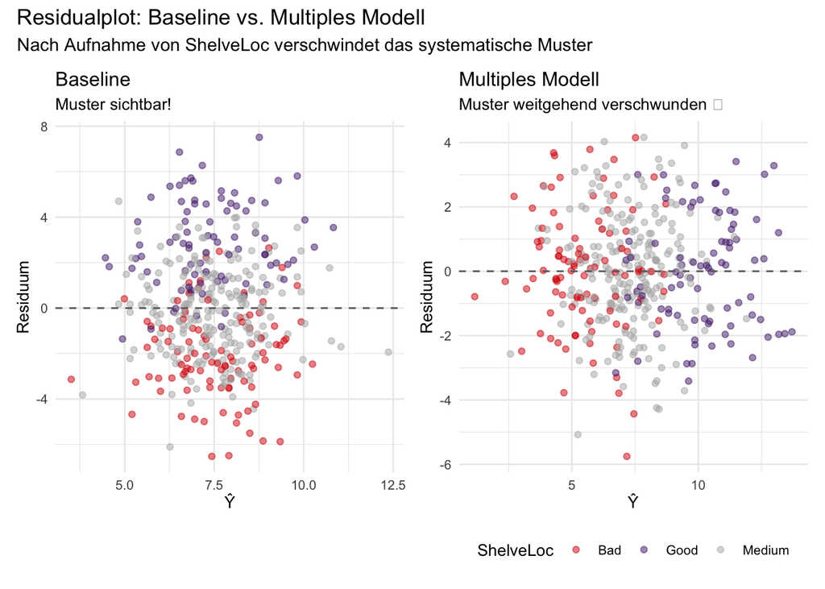

```r
pts_base <- augment(mod_baseline, data = tbl_carseats)
pts_mult <- augment(mod_multipel, data = tbl_carseats)

p1 <- pts_base %>%
  ggplot(aes(.fitted, .resid, color = ShelveLoc)) +
  geom_point(alpha = 0.5, size = 1.5) +
  geom_hline(yintercept = 0, linetype = "dashed", color = "#686868") +
  scale_color_manual(values = c("Bad" = "#D50006",
                                "Medium" = "#b3b2b2",
                                "Good" = "#502479")) +
  labs(title = "Baseline", subtitle = "Muster sichtbar!",
       x = "Ŷ", y = "Residuum") +
  theme_minimal(base_size = 10) + theme(legend.position = "none")

p2 <- pts_mult %>%
  ggplot(aes(.fitted, .resid, color = ShelveLoc)) +
  geom_point(alpha = 0.5, size = 1.5) +
  geom_hline(yintercept = 0, linetype = "dashed", color = "#686868") +
  scale_color_manual(values = c("Bad" = "#D50006",
                                "Medium" = "#b3b2b2",
                                "Good" = "#502479")) +
  labs(title = "Multiples Modell",
       subtitle = "Muster weitgehend verschwunden ✅",
       x = "Ŷ", y = "Residuum") +
  theme_minimal(base_size = 10) + theme(legend.position = "bottom")

p1 + p2 +
  plot_annotation(
    title    = "Residualplot: Baseline vs. Multiples Modell",
    subtitle = "Nach Aufnahme von ShelveLoc verschwindet das systematische Muster"
  )
```

## Step 6: Check for Multicollinearity

```r
# Korrelationsmatrix der numerischen Prädiktoren
tbl_carseats %>%
  select(Price, Advertising, Income, Age, Population) %>%
  cor() %>%
  round(3)
```

```
             Price Advertising Income    Age Population
Price        1.000       0.045 -0.057 -0.102     -0.012
Advertising  0.045       1.000  0.059 -0.005      0.266
Income      -0.057       0.059  1.000 -0.005     -0.008
Age         -0.102      -0.005 -0.005  1.000     -0.043
Population  -0.012       0.266 -0.008 -0.043      1.000
```

```r
# Variance Inflation Factor (VIF) — Faustregel: VIF > 5 problematisch
library(car)
vif(mod_multipel)
```

```
                GVIF Df GVIF^(1/(2*Df))
Price       1.004420  1        1.002207
Advertising 1.005294  1        1.002644
ShelveLoc   1.005989  2        1.001494
```

**HinweisRule of thumb: VIF-Interpretation**

| VIF | Assessment |
| --- | --- |
| 1–2 | No problem |
| 2–5 | Mild multicollinearity |
| 5–10 | Problematic — coefficients unstable |
| > 10 | Very problematic |

For our model: all VIF values are low → no multicollinearity problem.

## Step 7: Compute Performance-Scores

```r
filial_scored <- mod_multipel %>%
  get_regression_points() %>%
  mutate(performance_gap = residual) %>%
  arrange(performance_gap)

# Top 5 Underperformer
filial_scored %>%
  head(5) %>%
  select(ID, Sales, Sales_hat, residual) %>%
  gt() %>%
  fmt_number(columns = c(Sales, Sales_hat, residual), decimals = 2) %>%
  tab_style(
    style     = cell_fill(color = "#fff0f0"),
    locations = cells_body()
  ) %>%
  tab_options(table.font.size = "13px") %>%
  tab_header("Top 5 Underperformer (stärkste negative Residuen)")
```

Top 5 Underperformer (stärkste negative Residuen)

| ID | Sales | Sales_hat | residual |
| --- | --- | --- | --- |
| 51 | 1.42 | 7.17 | −5.75 |
| 107 | 0.16 | 5.24 | −5.08 |
| 210 | 3.02 | 7.45 | −4.43 |
| 45 | 4.16 | 8.45 | −4.29 |
| 101 | 4.11 | 8.35 | −4.24 |

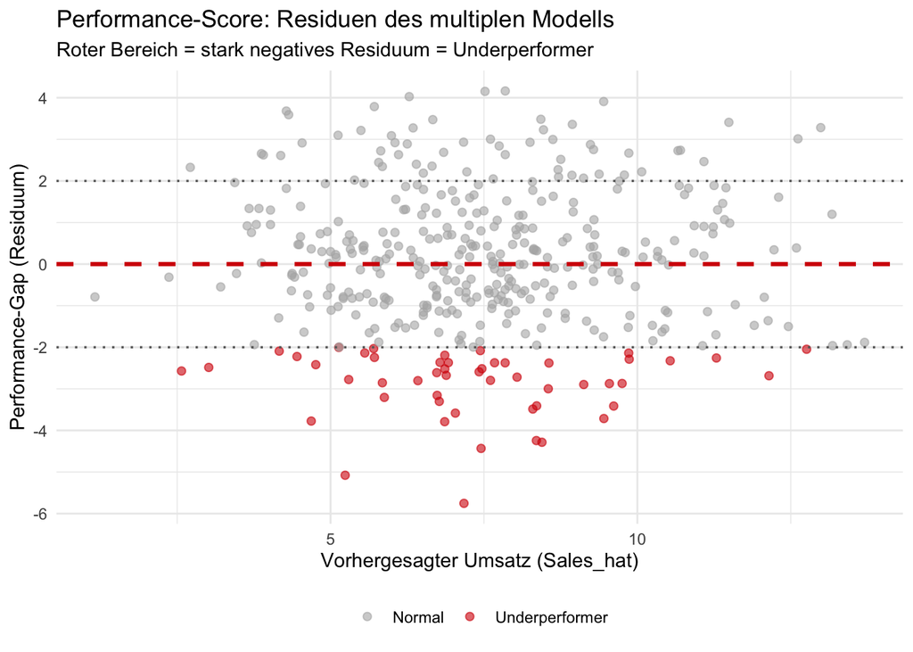

```r
filial_scored %>%
  ggplot(aes(x = Sales_hat, y = performance_gap)) +
  geom_point(
    aes(color = performance_gap < -2),
    alpha = 0.6, size = 1.8
  ) +
  geom_hline(yintercept = 0, color = "#D50006",
             linewidth = 1.1, linetype = "dashed") +
  geom_hline(yintercept = c(-2, 2), color = "#686868",
             linewidth = 0.6, linetype = "dotted") +
  scale_color_manual(values = c("FALSE" = "#b3b2b2",
                                "TRUE"  = "#D50006"),
                     labels = c("Normal", "Underperformer")) +
  labs(
    title    = "Performance-Score: Residuen des multiplen Modells",
    subtitle = "Roter Bereich = stark negatives Residuum = Underperformer",
    x = "Vorhergesagter Umsatz (Sales_hat)",
    y = "Performance-Gap (Residuum)",
    color = NULL
  ) +
  theme_minimal(base_size = 11) +
  theme(legend.position = "bottom")
```

## Overall Comparison: All Three Models

```r
mod_adv <- lm(Sales ~ Price + Advertising, data = tbl_carseats)

bind_rows(
  get_regression_summaries(mod_baseline) %>%
    mutate(modell = "① Sales ~ Price"),
  get_regression_summaries(mod_adv) %>%
    mutate(modell = "② Sales ~ Price + Advertising"),
  get_regression_summaries(mod_multipel) %>%
    mutate(modell = "③ Sales ~ Price + Advertising + ShelveLoc")
) %>%
  select(modell, r_squared, adj_r_squared, rmse) %>%
  gt() %>%
  fmt_number(columns = c(r_squared, adj_r_squared, rmse), decimals = 4) %>%
  tab_style(
    style     = cell_fill(color = "#fff8e1"),
    locations = cells_body(rows = 2)
  ) %>%
  tab_style(
    style     = cell_fill(color = "#f0fff0"),
    locations = cells_body(rows = 3)
  ) %>%
  tab_options(table.font.size = "13px") %>%
  tab_footnote("Grün = bestes Modell | Gelb = mittleres Modell")
```

| modell | r_squared | adj_r_squared | rmse |
| --- | --- | --- | --- |
| ① Sales ~ Price | 0.1980 | 0.1960 | 2.5260 |
| ② Sales ~ Price + Advertising | 0.2820 | 0.2780 | 2.3903 |
| ③ Sales ~ Price + Advertising + ShelveLoc | 0.6080 | 0.6050 | 1.7649 |

Grün = bestes Modell | Gelb = mittleres Modell

**WichtigSummary of the Demo**

[output not shown]

**Next Step (Lab 3):** Use the residuals from the multiple model as a **performance score** to create the list of underperformers and draft the managerial memo.